# using `ggstatsplot` with the `purrr` package

Indrajeet Patil

2018-12-06

# Why `purrr`?

Most of the `ggstatsplot` functions have `grouped_` variants, which are designed to quickly run the same `ggstatsplot` function across multiple levels of a **single** grouping variable. Although this function is useful for data exploration, it has two strong weaknesses-

- The arguments applied to `grouped_` function call are applied uniformly to all levels of the grouping variable when we might want to customize them for different levels of the grouping variable.
- Only one grouping variable can be used to repeat the analysis when in reality there can be a combination of grouping variables and the operation needs to be repeated for all resulting combinations.

We will see how to overcome this limitation by combining `ggstatsplot` with the `purrr` package.

**Note:**

- Unlike the typical function call for `ggstatsplot` functions where arguments can be quoted (`"x"`) or unquoted (`x`), while using `purrr::pmap`, we **must** *quote* the arguments.
- You can use `ggplot2` themes from extension packages (like `ggthemes`).
- If you’d like some more background or an introduction to the purrr package, please see [this tutorial](https://jennybc.github.io/purrr-tutorial/).

# Introduction and methodology

For all the examples in this vignette we are going to build `list`s of things that we will pass along to `purrr` which will in turn return a list of plots that will be passed to `combine_plots`. As the name implies `combine_plots` merges the individual plots into one bigger plot with common labeling and aesthetics.

What are these `lists` that we are building? The lists correspond to the parameters in our `ggstatsplot` function like `ggbetweenstats`. If you look at the help file for `?ggbetweenstats` for example the very first parameter it wants is the `data` file we’ll be using. We can also pass it different `titles` of even `ggtheme`s.

You can pass:

- A single `chr` string such as `xlab = "Continent"` or numeric such as `nboot = 25` in which case it will be reused/recycled as many times as needed.
- A vector of values such as mean.label.size = c(3, 4, 5) in which case it will be coerced to a list and checked for the right class (in this case `int`) and the right quantity of entries in the vector i.e., mean.label.size = c(3, 4) will fail if we’re trying to make three plots.
- A list; either named `data = year_list` or created as you go `outlier.label.color = list("#56B4E9", "#009E73", "#F0E442")`. Any list will be checked for the right class (in this case `chr`) and the right quantity of entries in the list.

# `ggbetweenstats`

```r
library(ggstatsplot)

# for reproducibility
set.seed(123)

# let's split the dataframe and create a list by years of interest
year_list <- gapminder::gapminder %>%
  dplyr::filter(
    .data = .,
    year == 1967 |
    year == 1987 |
    year == 2007,
    continent != "Oceania"
  ) %>%
  base::split(x = ., f = .$year, drop = TRUE)

# this created a list with 3 elements, one for each year we want
# you can check the structure of the file for yourself
str(year_list[1])
```

```
#> List of 1
#>  $ 1967:Classes 'tbl_df', 'tbl' and 'data.frame':    140 obs. of  6 variables:
#>   ..$ country  : Factor w/ 142 levels "Afghanistan",..: 1 2 3 4 5 7 8 9 10 11 ...
#>   ..$ continent: Factor w/ 5 levels "Africa","Americas",..: 3 4 1 1 2 4 3 3 4 1 ...
#>   ..$ year     : int [1:140] 1967 1967 1967 1967 1967 1967 1967 1967 1967 1967 ...
#>   ..$ lifeExp  : num [1:140] 34 66.2 51.4 36 65.6 ...
#>   ..$ pop      : int [1:140] 11537966 1984060 12760499 5247469 22934225 7376998 202182 62821884 9556500 2427334 ...
#>   ..$ gdpPercap: num [1:140] 836 2760 3247 5523 8053 ...
```

```r
# checking the length of the list and the names of each element
length(year_list)
```

```
#> [1] 3
```

```r
names(year_list)
```

```
#> [1] "1967" "1987" "2007"
```

Now that we have the data divided into the three relevant years in a list we’ll turn to `purrr::pmap` to create a list of ggplot objects that we’ll make use of stored in `plot_list`. When you look at the documentation for `?pmap` it will accept `.l` which is a list of lists. The length of .l determines the number of arguments that `.f` will be called with. List names will be used if present. `.f` is the function we want to apply. In our case `.f = ggstatsplot::ggbetweenstats`.

So let’s keep building `.l`.First is `data = year_list`, the x & y axes are constant in all three plots so we pass the variable name as a string `x = "continent"`. Same with the label we’ll use for outliers where needed. For demonstration purposes let’s assume we want the outliers on each plot to be a different color. Not actually recommending it just demonstrating what’s possible. We build a list on the fly with `outlier.label.color = list("#56B4E9", "#009E73", "#F0E442")`. The rest of the code shows you a wide variety of possibilities and we won’t catalog them here.

```r
plot_list <- purrr::pmap(
  .l = list(
    data = year_list,
    x = "continent",
    y = "lifeExp",
    outlier.tagging = TRUE,
    outlier.label = "country",
    outlier.label.color = list(
      "#56B4E9",
      "#009E73",
      "#F0E442"
    ),
    xlab = "Continent",
    ylab = "Life expectancy",
    title = list(
      "Year: 1967",
      "Year: 1987",
      "Year: 2007"
    ),
    type = list("r", "bf", "np"),
    pairwise.comparisons = TRUE,
    pairwise.display = list("s", "ns", "all"),
    pairwise.annotation = list("asterisk", "asterisk", "p.value"),
    p.adjust.method = list("hommel", "bonferroni", "BH"),
    nboot = 25,
    conf.level = list(0.99, 0.95, 0.90),
    mean.label.size = c(3, 4, 5),
    k = list(1, 2, 3),
    effsize.type = list(
      NULL,
      "partial_omega",
       "partial_eta"
    ),
    plot.type = list("box", "boxviolin", "violin"),
    mean.ci = list(TRUE, FALSE, FALSE),
    package = list("nord", "ochRe", "awtools"),
    palette = list("aurora", "parliament", "ppalette"),
    ggtheme = list(
      ggthemes::theme_stata(),
      ggplot2::theme_classic(),
      ggthemes::theme_fivethirtyeight()
    ),
    ggstatsplot.layer = list(FALSE, FALSE, FALSE),
    sample.size.label = list(TRUE, FALSE, TRUE),
    messages = FALSE
  ),
  .f = ggstatsplot::ggbetweenstats
)
```

The final step is to pass the `plot_list` object we just created to the `combine_plots` function. While each of the 3 plots already has labeling information `combine_plots` gives us an opportunity to add additional details to the merged plots and specify the layout in rows and columns.

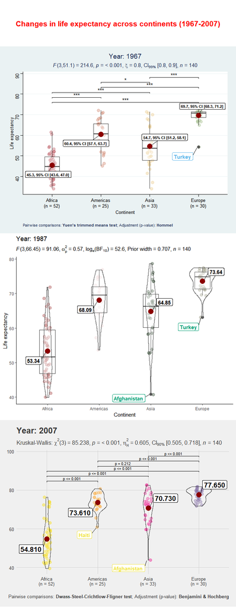

```r
# combining all individual plots from the list into a single plot using combine_plots function
ggstatsplot::combine_plots(
  plotlist = plot_list,
  title.text = "Changes in life expectancy across continents (1967-2007)",
  title.color = "red",
  nrow = 3,
  ncol = 1
)
```

# `ggscatterstats`

For the next example lets use the same methodology on different data and using `ggscatterstats` to produce scatterplots combined with marginal histograms/boxplots/density plots with statistical details added as a subtitle.

For data we’ll use `movies_wide` which is from IMDB and part of the `ggstatsplot` package. Since it’s a large dataset with some relatively small categories like **NC-17** we’ll sample only one quarter of the data and completely drop NC-17 using `dplyr`. Once again we’ll feed `purrr::pmap` a list of lists via `.l` and for `.f` we’ll specify `.f = ggstatsplot::ggscatterstats`.

This time we’ll put all the code in one block…

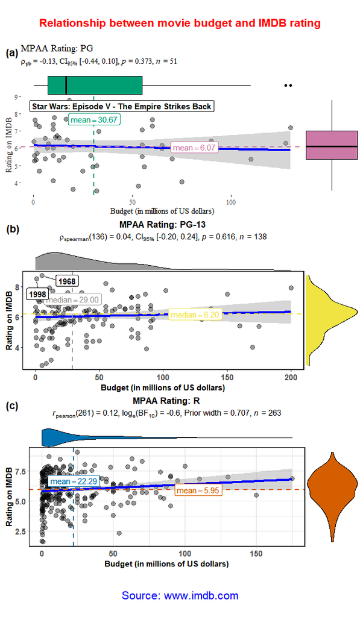

```r
# for reproducibility
set.seed(123)

mpaa_list <- ggstatsplot::movies_wide %>%
  dplyr::filter(.data = ., mpaa != "NC-17") %>%
  dplyr::sample_frac(tbl = ., size = 0.25) %>%
  base::split(x = ., f = .$mpaa, drop = TRUE)

plot_list <- purrr::pmap(
  .l = list(
    data = mpaa_list,
    x = "budget",
    y = "rating",
    xlab = "Budget (in millions of US dollars)",
    ylab = "Rating on IMDB",
    title = list(
      "MPAA Rating: PG",
      "MPAA Rating: PG-13",
      "MPAA Rating: R"
    ),
    label.var = list("title", "year", "length"),
    label.expression = list(
       "rating > 8.5 &
         budget < 100",
       "rating > 8 & budget < 50",
       "rating > 9 & budget < 10"
     ),
    type = list("r", "np", "bf"),
    method = list(MASS::rlm, "lm", "lm"),
    nboot = 25,
    marginal.type = list("boxplot", "density", "violin"),
    centrality.para = list("mean", "median", "mean"),
    xfill = list("#009E73", "#999999", "#0072B2"),
    yfill = list("#CC79A7", "#F0E442", "#D55E00"),
    ggtheme = list(
      ggthemes::theme_tufte(),
      ggplot2::theme_classic(),
      ggplot2::theme_light()
    ),
    ggstatsplot.layer = list(FALSE, TRUE, TRUE),
    messages = FALSE
  ),
  .f = ggstatsplot::ggscatterstats
)

# combining all individual plots from the list into a single plot using combine_plots function
ggstatsplot::combine_plots(
  plotlist = plot_list,
  title.text = "Relationship between movie budget and IMDB rating",
  caption.text = "Source: www.imdb.com",
  caption.size = 16,
  title.color = "red",
  caption.color = "blue",
  nrow = 3,
  ncol = 1,
  labels = c("(a)","(b)","(c)","(d)")
)
```

The remainder of the examples vary in content but follow the exact same methodology as the earlier examples.

# `ggcorrmat`

```r
# splitting the dataframe by cut and creting a list
# let's leave out "fair" cut
# also, to make this fast, let's only use 5% of the sample
cut_list <- ggplot2::diamonds %>%
  dplyr::sample_frac(tbl = ., size = 0.05) %>%
  dplyr::filter(.data = ., cut != "Fair") %>%
  base::split(x = ., f = .$cut, drop = TRUE)

# this created a list with 4 elements, one for each quality of cut
# you can check the structure of the file for yourself
# str(cut_list)

# checking the length and names of each element
length(cut_list)
```

```
#> [1] 4
```

```r
names(cut_list)
```

```
#> [1] "Good"      "Very Good" "Premium"   "Ideal"
```

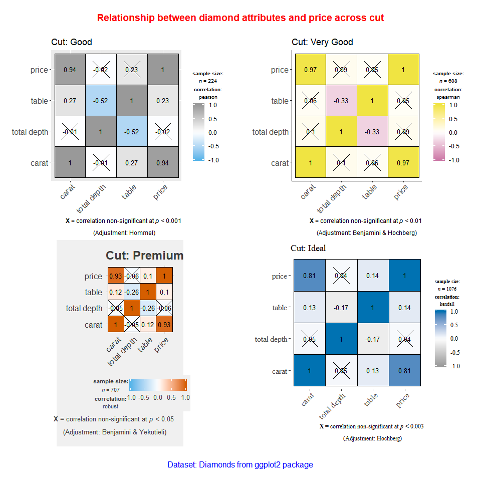

```r
# running function on every element of this list note that if you want the same
# value for a given argument across all elements of the list, you need to
# specify it just once
plot_list <- purrr::pmap(
  .l = list(
    data = cut_list,
    cor.vars = list(c("carat", "depth", "table", "price")),
    cor.vars.names = list(c(
      "carat",
      "total depth",
      "table",
      "price"
    )),
    corr.method = list("pearson", "np", "robust", "kendall"),
    title = list("Cut: Good", "Cut: Very Good", "Cut: Premium", "Cut: Ideal"),
    # note that we are changing both p-value adjustment method *and*
    # significance level to display the significant correlations in the
    # visualization matrix
    p.adjust.method = list("hommel", "fdr", "BY", "hochberg"),
    sig.level = list(0.001, 0.01, 0.05, 0.003),
    lab.size = 3.5,
    colors = list(
      c("#56B4E9", "white", "#999999"),
      c("#CC79A7", "white", "#F0E442"),
      c("#56B4E9", "white", "#D55E00"),
      c("#999999", "white", "#0072B2")
    ),
    ggstatsplot.layer = FALSE,
    ggtheme = list(
      ggplot2::theme_grey(),
      ggplot2::theme_classic(),
      ggthemes::theme_fivethirtyeight(),
      ggthemes::theme_tufte()
    ),
    messages = FALSE
  ),
  .f = ggstatsplot::ggcorrmat
)

# combining all individual plots from the list into a single plot using
# `combine_plots` function
ggstatsplot::combine_plots(
  plotlist = plot_list,
  title.text = "Relationship between diamond attributes and price across cut",
  title.size = 14,
  title.color = "red",
  caption.text = "Dataset: Diamonds from ggplot2 package",
  caption.size = 12,
  caption.color = "blue",
  nrow = 2
)
```

# `gghistostats`

```r
# for reproducibility
set.seed(123)

# libraries needed
library(ggthemes)

# let's split the dataframe and create a list by continent
# let's leave out Oceania because it has just two data points
continent_list <- gapminder::gapminder %>%
  dplyr::filter(.data = ., year == 2007, continent != "Oceania") %>%
  base::split(x = ., f = .$continent, drop = TRUE)

# this created a list with 4 elements, one for each continent
# you can check the structure of the file for yourself
# str(continent_list)

# checking the length and names of each element
length(continent_list)
```

```
#> [1] 4
```

```r
names(continent_list)
```

```
#> [1] "Africa"   "Americas" "Asia"     "Europe"
```

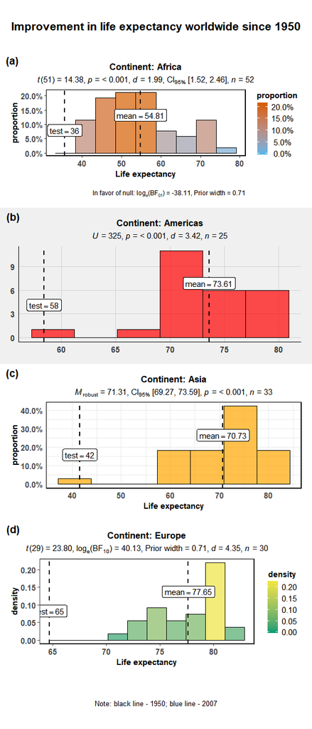

```r
# running function on every element of this list note that if you want the same
# value for a given argument across all elements of the list, you need to
# specify it just once
plot_list <- purrr::pmap(
  .l = list(
    data = continent_list,
    x = "lifeExp",
    xlab = "Life expectancy",
    test.value = list(35.6, 58.4, 41.6, 64.7),
    type = list("p", "np", "r", "bf"),
    bf.message = list(TRUE, FALSE, FALSE, FALSE),
    title = list(
      "Continent: Africa",
      "Continent: Americas",
      "Continent: Asia",
      "Continent: Europe"
    ),
    bar.measure = list("proportion", "count", "proportion", "density"),
    fill.gradient = list(TRUE, FALSE, FALSE, TRUE),
    low.color = list("#56B4E9", "white", "#999999", "#009E73"),
    high.color = list("#D55E00", "white", "#F0E442", "#F0E442"),
    bar.fill = list("white", "red", "orange", "blue"),
    centrality.color = "black",
    test.value.line = TRUE,
    test.value.color = "black",
    centrality.para = "mean",
    ggtheme = list(
      ggplot2::theme_classic(),
      ggthemes::theme_fivethirtyeight(),
      ggplot2::theme_minimal(),
      ggthemes::theme_few()
    ),
    messages = FALSE
  ),
  .f = ggstatsplot::gghistostats
)

# combining all individual plots from the list into a single plot using combine_plots function
ggstatsplot::combine_plots(
  plotlist = plot_list,
  title.text = "Improvement in life expectancy worldwide since 1950",
  caption.text = "Note: black line - 1950; blue line - 2007",
  nrow = 4,
  ncol = 1,
  labels = c("(a)", "(b)", "(c)", "(d)")
)
```

# `ggpiestats`

```r
# let's split the dataframe and create a list by passenger class
class_list <- ggstatsplot::Titanic_full %>%
  base::split(x = ., f = .$Class, drop = TRUE)

# this created a list with 4 elements, one for each class
# you can check the structure of the file for yourself
# str(class_list)

# checking the length and names of each element
length(class_list)
```

```
#> [1] 4
```

```r
names(class_list)
```

```
#> [1] "1st"  "2nd"  "3rd"  "Crew"
```

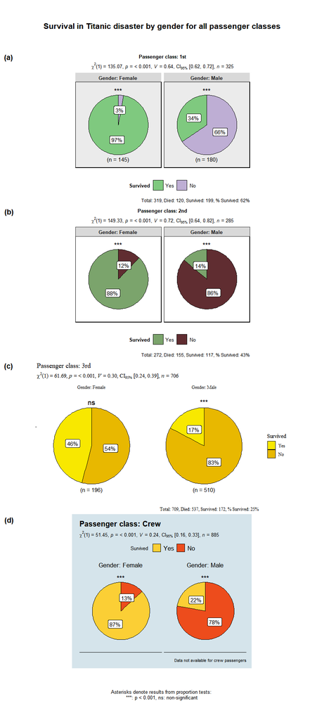

```r
# running function on every element of this list note that if you want the same
# value for a given argument across all elements of the list, you need to
# specify it just once
plot_list <- purrr::pmap(
  .l = list(
    data = class_list,
    main = "Survived",
    condition = "Sex",
    nboot = 10,
    facet.wrap.name = "Gender",
    title = list(
      "Passenger class: 1st",
      "Passenger class: 2nd",
      "Passenger class: 3rd",
      "Passenger class: Crew"
    ),
    caption = list(
      "Total: 319, Died: 120, Survived: 199, % Survived: 62%",
      "Total: 272, Died: 155, Survived: 117, % Survived: 43%",
      "Total: 709, Died: 537, Survived: 172, % Survived: 25%",
      "Data not available for crew passengers"
    ),
    package = list("RColorBrewer", "ghibli", "palettetown", "yarrr"),
    palette = list("Accent", "MarnieMedium1", "pikachu", "nemo"),
    ggtheme = list(
      ggplot2::theme_grey(),
      ggplot2::theme_bw(),
      ggthemes::theme_tufte(),
      ggthemes::theme_economist()
    ),
    ggstatsplot.layer = list(TRUE, TRUE, FALSE, FALSE),
    sample.size.label = list(TRUE, FALSE, TRUE, FALSE),
    messages = FALSE
  ),
  .f = ggstatsplot::ggpiestats
)

# combining all individual plots from the list into a single plot using combine_plots function
ggstatsplot::combine_plots(
  plotlist = plot_list,
  title.text = "Survival in Titanic disaster by gender for all passenger classes",
  caption.text = "Asterisks denote results from proportion tests: \n***: p < 0.001, ns: non-significant",
  nrow = 4,
  ncol = 1,
  labels = c("(a)","(b)","(c)", "(d)")
)
```

# Suggestions

If you find any bugs or have any suggestions/remarks, please file an issue on GitHub: https://github.com/IndrajeetPatil/ggstatsplot/issues

# Session Information

For details, see- https://indrajeetpatil.github.io/ggstatsplot/articles/web_only/session_info.html